# **Batchevaluation wrapper: Short introduction**

## loading library

Sometime loading of ‘magrittr’,‘purrr’ and ‘dplyr’ with `Batchevaluation` package is deprecated, therefore, it is recommended to load all of these together.

```r
library(magrittr)
library(purrr)
library(dplyr)
library(Batchevaluation)
```

## Loading data in R

If the data files are already on your computer, you can use this step. If you want to download data from Expression Atlas, skip this part and go directly to “Downloading data from Expression Atlas”.

**Recommendation:** Microarray input data should be preprocessed- appropriately back-ground corrected without any normalization step, probe-to-gene level mapped and log-transformed. It is also recommended to remove low-expressed genes from data if possible. For bulk-RNaseq data, it should be count matrix .

**Steps:**

- Put the data files in `.Rdata` format in a directory containing only them. (The R objects contained in those files must be either `SummarizedExperiment` or `ExpressionSet` experiment.)
- Load all the experiments in a list using the function `load_experiments`

```r
experiments <- load_experiments('directory_path')
experiments<-load_experiments('./')
```

Example Microarray data is provided in **example1** folder of the package.

## Downloading data from Expression Atlas

If you want to use data from Expression Atlas that can be downloaded in `.Rdata` format, you can use the function `download_experiments_from_ExpressionAtlas` in this way :

```r
experiments <- download_experiments_from_ExpressionAtlas('E-MTAB-3718','E-MTAB-3725','E-GEOD-44366','E-GEOD-74747')
```

This downloads the experiments in a new directory called **“experiments”** in your working directory and loads all the experiments in R within a list, using `load_experiments` function. After having loaded the experiments, you will get a list of either `SummarizedExperiment` or list of `ExpressionSet` objects.

**Caution**: Avoid mixing experiments of `SummarizedExperiment` with `ExpressionSet`. Experiments can only belong from any one of the classes only. All the selected experiments should have same gene id format.

Example of loaded data:

```
> experiments
$GSE1297_rawdata.Rdata
ExpressionSet (storageMode: lockedEnvironment)
assayData: 8872 features, 29 samples
  element names: exprs
protocolData: none
phenoData
  rowNames: 1 2 ... 3 (29 total)
  varLabels: ID Assay ... Batch (9 total)
  varMetadata: labelDescription
featureData: none
experimentData: use 'experimentData(object)'
Annotation:

$GSE1711_rawdata.Rdata
ExpressionSet (storageMode: lockedEnvironment)
assayData: 12386 features, 24 samples
  element names: exprs
protocolData: none
phenoData
  sampleNames: SAMPLE212704SUB4576 SAMPLE212705SUB4576 ... SAMPLE212727SUB4576 (24 total)
  varLabels: AtlasAssayGroup age ... biosource_type (9 total)
  varMetadata: labelDescription
featureData: none
experimentData: use 'experimentData(object)'
Annotation:
```

## Removing the isolated experiments

To correct the `batch effect`, one needs to take the biological characteristics of the samples into account (`Tissue` in our example). If no sample of an experiment shares biological characteristics with samples from other batches, it is not possible to correct batch effect with these batches because one cannot distinguish the biological difference from the artifact. The function `remove_isolated_experiments` removes the isolated experiments and plots graphs of intersections between the experiments before and after removal.

```r
experiments %<>% remove_isolated_experiments('Tissue')
```

**WARNING:** this function only removes the isolated experiment. Although it is still possible that two or more unconnected groups of experiments remain, within which the experiments are connected. In this case, batch effect correction is not possible and one will have to choose a group of experiments manually.

## Merging experiments in a single dataset

The function `merge_experiments` merges all the experiments in the list in a single `SummarizedExperiment` or `ExpressionSet` object and doesn’t perform any correction. This function has two additional arguments `log` and `filter` (respectively set to `TRUE` and `FALSE` by default).

- The `log` argument determines whether to perform log transformation on the data (recommended for bulk RNAseq).
- The `filter` argument determines whether to filter genes for which all the samples of a batch have zero-counts. Set it to `TRUE` if you have issues in running ComBat at the next step.

```r
experiments %<>% merge_experiments
#OR
experiments %<>% merge_experiments(log=TRUE,filter=FALSE)
```

`experiments` is now an only `ExpressionSet` object containing the information about batches both in its `@metadata` and `@colData` slots :

```
ExpressionSet (storageMode: lockedEnvironment)
assayData: 8872 features, 56 samples
  element names: exprs
protocolData: none
phenoData
  sampleNames: GSM21215.cel GSM21218.cel ... GSM697308.CEL (56 total)
  varLabels: ID Assay ... batch (10 total)
  varMetadata: labelDescription
featureData: none
experimentData: use 'experimentData(object)'
Annotation:
```

**Caution:** Sometimes during merging experiment, phenodata (SDRF) file gets corrupted, hence, it is advised to always check meta-data before proceeding further.

## Correcting batch effect

The function `batch_correction` performs various methods of batch-correction on a given merged dataset and output batch-corrected data as a list.

Short detail of methods implemented in `batch_correction` function are given below-

- For Microarray, `batch_correction` function has following batch correction methods-
  - **limma**- default limma setting, more detail about the method can be learnt from Limma [documentation](https://www.bioconductor.org/packages/release/bioc/manuals/limma/man/limma.pdf).
  - **GFS**- Gene Fuzzy Score, more detail about the method can be learnt from [publication](https://bmcbioinformatics.biomedcentral.com/articles/10.1186/s12859-016-1327-8).
  - **Robust quantile normalization**- quantile normalisation method from PreprocessCore package. More information can be obtained from their [documentation](https://www.bioconductor.org/packages//2.7/bioc/html/preprocessCore.html).
  - **ComBat**- implemented from SVA package. More information can be obtained from their [documentation](https://bioconductor.riken.jp/packages/3.0/bioc/html/sva.html). In the current `batch_correction` method, there are two versions of ComBat- 1) **ComBat1**- for parametric adjustment and, 2) **ComBat2** - for non-parametric adjustment, mean-only version.
  - **Q_ComBat** - is Quantile+ parametric adjustment of ComBat.
  - **MNN** - default mnnCorrect function from batchelor package. More information can be obtained from their [documentation](https://bioconductor.org/packages/release/bioc/html/batchelor.html).
  - **naiveRandRUV_HK** - default naiveRandRUV using Human HK genes from RUVnormalize package. More information can be obtained from their [documentation](https://bioconductor.org/packages/release/bioc/html/RUVnormalize.html). The Human Housekeeping gene list is from this [publication](https://academic.oup.com/gigascience/article/8/9/giz106/5570567). No. of confounders were estimated using both “leek” and “be” method and then least no. of estimated confounders were used as input for all variants of **naiveRandRUV** method.
  - **Q_naiveRandRUV_HK** - is Qunatile+ naiveRandRUV_HK
  - **naiveRandRUV_empi.controls** - default naiveRandRUV using data-empirically derived HK genes from RUVnormalize package.
  - **Q_naiveRandRUV_empi.controls** -is Qunatile+ naiveRandRUV_empi.controls.
- For bulk-RNAseq, `batch_correction` function has the following batch correction methods-
  - **limma**- default limma setting, more detail about the method can be learnt from Limma [documentation](https://www.bioconductor.org/packages/release/bioc/manuals/limma/man/limma.pdf).
  - **ComBat**- implemented from SVA package. More information can be obtained from their [documentation](https://bioconductor.riken.jp/packages/3.0/bioc/html/sva.html).
  - **ComBat_seq** - RNAseq version of ComBat, now implemented in `SVA` package. More information can be obtained from this [publication](https://www.biorxiv.org/content/10.1101/2020.01.13.904730v1).
  - **MNN** - default mnnCorrect function from batchelor package. More information can be obtained from their [documentation](https://bioconductor.org/packages/release/bioc/html/batchelor.html).
  - **RUVs** - default RUVs function from RUVSeq package.Here, k=1 is used. More information can be obtained from their [documentation](https://bioconductor.org/packages/release/bioc/html/RUVSeq.html).
  - **scBatch** - batch correction method implemented in scBatch package. More information can be obtained from their [publication](https://academic.oup.com/bioinformatics/article/34/15/2634/4916062).

This function has following arguments-

- The `experiment` argument is the input merged dataset.
- The `model` argument is a R formula mentioning the biological factor to take into account during correction.
- The `batch` argument is a meta-data column which has information about batch-label.
- The `k` argument is a no. of confounders for RUV methods and denotes the “number of factors of unwanted variation to remove”. If k is not provided it will then be estimated from input data.
- The `filter` argument specifies the gene label for the given dataset. It Should be one of the following string- ‘symbol’, ‘ensembl_gene_id’ or ‘entrezgene_id’ depending on the gene label for the given dataset.

Since, this merged dataset had some issues while merging, phenodata was added separately. Phenodata is also available with the package in `data` folder and can be accessed like this:

```r
load("~/Batchevaluation/data/pheno.example1.Rdata")
experiments <- ExpressionSet(exprs(experiments), phenoData=pheno.experiment1)
```

After assigning phenodata, batch correction can be performed like this:

```r
result <- batch_correction(experiment= experiments,model=~Disease, batch = "batch",'symbol')
```

Result is the list of batch-corrected data:

```
> summary(result)
                                  Length Class         Mode
data.limma                        1      ExpressionSet S4
data.GFS                          1      ExpressionSet S4
data.quantile                     1      ExpressionSet S4
data.ComBat1                      1      ExpressionSet S4
data.ComBat2                      1      ExpressionSet S4
data.Q_ComBat                     1      ExpressionSet S4
data.mnncorrect                   1      ExpressionSet S4
data.Q_naiveRandRUV_HK            1      ExpressionSet S4
data.naiveRandRUV_HK              1      ExpressionSet S4
data.naiveRandRUV_empi.controls   1      ExpressionSet S4
data.Q_naiveRandRUV_empi.controls 1      ExpressionSet S4
```

## Assessment of batch-correction methods

The function `batch_evaluation` performs various evaluations on batch-corrected data and output performance list of each method. Since there are no. of ways batch-correction can be evaluated and each method has some limitation, we have used a cocktail of methods to perform analysis. This function has both PCA-inspired as well as biology inspired qualitative assessment protocol for batch-correction.

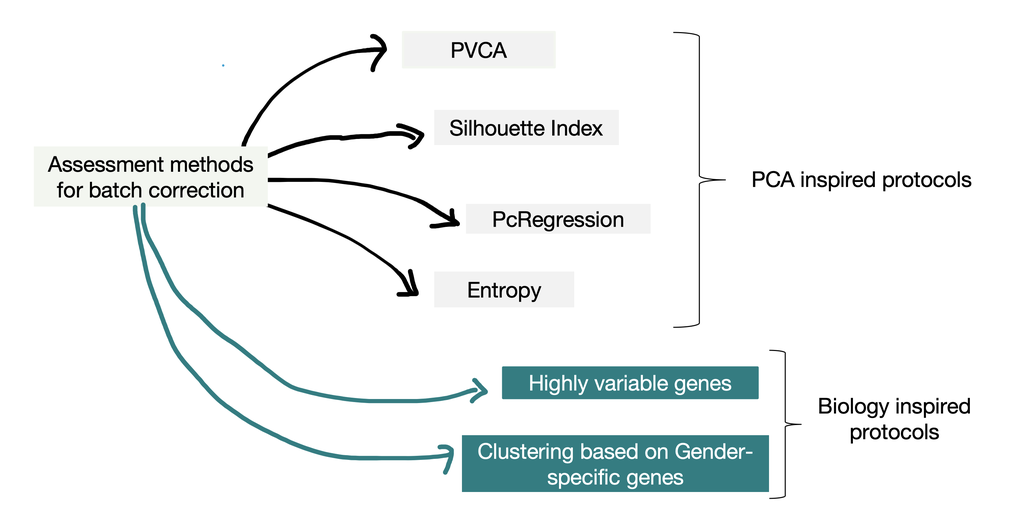

Overview of implemented assessment methods.

Short detail of methods implemented in `batch_evaluation` function is given below-

- **pvca**- A function for principal variance component analysis. The function is written based on the ‘pvcaBatchAssess’ function of the PVCA R package and slightly changed to make it more efficient and flexible for both microarray and bulk RNAseq gene-expression data. From https://github.com/dleelab/pvca.
- **silhouette**- Determine `batch effect` using the silhouette coefficient (adopted from scone) with default setting (nPcs=3). Taken from `kBET` [package](https://github.com/theislab/kBET).
- **pcRegression**- Determines `batch effect` by a linear model fit of principal components and a batch (categorical) variable with a default setting (n_top=20). Taken from `kBET` [package](https://github.com/theislab/kBET).
- **entropy**- Determines the batch effect by computing the entropy of mixing. It is a parameter to quantify the extent of the intermingling of cells from different batches. Taken from `MNN` [package](https://github.com/MarioniLab/MNN2017).For calculation, first two Pcs are used as input. Since,depending on no. of samples in merged dataset, it is important to choose N1 and N2 for Batchentropy calculation, we have put both arguments as variables here.
- **gender**- Determines `overfitting issue` using the silhouette coefficient with default setting (nPcs=3). Method computes silhouette coefficient using gender-specific genes and gender/sex meta-data column. Higher the silhouette coefficient, lesser overfitting will be expected because of `batch-correction`.**Warning**- If phenodata(SDRF) file doesn’t contain sex/Gender/Sex/gender column, than this analysis will be skipped.
- **HVG.intersection**- This analysis calculates fraction of conserved highly variable genes (HVG) according to Brennecke et al., 2013 [publication](https://www.nature.com/articles/nmeth.2645). This indirectly reflects whether biological heterogeneity is preserved or not during `batch-correction`. For this calculation, we consider the ratio of HVG genes after correction/conserved HVG genes among different batches.
- **HVG.union**- This calculation also accounts for perseverance of biological heterogeneity by measuring ratio of conservation of HVG genes after batch correction. This function calculates ratio of number of conserved HVG after batch correction/ Union of HVG genes among all the batches. Therefore, this function is less stringent compared to `HVG.intersection` function.

This function has following arguments-

- The `result` argument is a list of wrapped batch-corrected experiments obtained from the last step (‘batch_correction’).
- The `batch.factors` is a list of factors to perform `PVCA` analysis. Along with `batch` as factor, one `biological factor` which can be used to assess over-fitting should be provided. Providing more than one `biological factor` here, will create issues while plotting the results in next step.
- The `experiment` argument is the input merged dataset.
- The `N1` is the number of randomly picked samples for the BatchEntropy function.
- The `N2` is the number of nearest neighbours of the sample (from all batches) to check (for BatchEntropy function).
- The `filter` argument specifies the gene label for the given dataset. It Should be one of following string- ‘symbol’, ‘ensembl_gene_id’ or ‘entrezgene_id’ depending on the gene label for the given dataset.

Assessment of batch-corrected data can be performed like this:

```r
assessment <- batch_evaluation(result, batch.factors=c("batch","sex"), experiments,10,10,'symbol')
```

Result is the nested list of evaluation scores for each of the evaluation protocols.

```
> assessment

$pvca
# A tibble: 2 x 11
  data.limma data.GFS data.quantile data.ComBat1 data.ComBat2 data.Q_ComBat data.mnncorrect data.Q_naiveRan…
*      <dbl>    <dbl>         <dbl>        <dbl>        <dbl>         <dbl>           <dbl>            <dbl>
1   8.64e-10   0.0326      9.99e- 1 0.0000000153 0.0000000783      3.60e-12          0.0122   0.000000000313
2   7.14e- 2   0.0261      4.75e-12 0.0708       0.0718            7.55e- 2          0.0700   0.0760
# … with 3 more variables: data.naiveRandRUV_HK <dbl>, data.naiveRandRUV_empi.controls <dbl>,
#   data.Q_naiveRandRUV_empi.controls <dbl>

$silhouette
# A tibble: 1 x 11
  data.limma data.GFS data.quantile data.ComBat1 data.ComBat2 data.Q_ComBat data.mnncorrect data.Q_naiveRan…
*      <dbl>    <dbl>         <dbl>        <dbl>        <dbl>         <dbl>           <dbl>            <dbl>
1   -0.00793   0.0853         0.744     -0.00849     -0.00743      -0.00498          0.0726         -0.00199
# … with 3 more variables: data.naiveRandRUV_HK <dbl>, data.naiveRandRUV_empi.controls <dbl>,
#   data.Q_naiveRandRUV_empi.controls <dbl>

$pcRegression
# A tibble: 1 x 11
  data.limma data.GFS data.quantile data.ComBat1 data.ComBat2 data.Q_ComBat data.mnncorrect data.Q_naiveRan…
*      <dbl>    <dbl>         <dbl>        <dbl>        <dbl>         <dbl>           <dbl>            <dbl>
1          0        0         0.872            0            0             0               0                0
# … with 3 more variables: data.naiveRandRUV_HK <dbl>, data.naiveRandRUV_empi.controls <dbl>,
#   data.Q_naiveRandRUV_empi.controls <dbl>

$entropy
# A tibble: 1 x 11
  data.limma data.GFS data.quantile data.ComBat1 data.ComBat2 data.Q_ComBat data.mnncorrect data.Q_naiveRan…
*      <dbl>    <dbl>         <dbl>        <dbl>        <dbl>         <dbl>           <dbl>            <dbl>
1          0        0             0            0            0             0               0                0
# … with 3 more variables: data.naiveRandRUV_HK <dbl>, data.naiveRandRUV_empi.controls <dbl>,
#   data.Q_naiveRandRUV_empi.controls <dbl>

$gender
# A tibble: 1 x 11
  data.limma data.GFS data.quantile data.ComBat1 data.ComBat2 data.Q_ComBat data.mnncorrect data.Q_naiveRan…
*      <dbl>    <dbl>         <dbl>        <dbl>        <dbl>         <dbl>           <dbl>            <dbl>
1     0.0549 -0.00168        0.0198       0.0502       0.0550         0.133           0.107            0.123
# … with 3 more variables: data.naiveRandRUV_HK <dbl>, data.naiveRandRUV_empi.controls <dbl>,
#   data.Q_naiveRandRUV_empi.controls <dbl>

$HVG.intersection
# A tibble: 1 x 11
  data.limma data.GFS data.quantile data.ComBat1 data.ComBat2 data.Q_ComBat data.mnncorrect data.Q_naiveRan…
*      <dbl>    <dbl>         <dbl>        <dbl>        <dbl>         <dbl>           <dbl>            <dbl>
1          1   0.0395         0.355            1            1             1               1                0
# … with 3 more variables: data.naiveRandRUV_HK <dbl>, data.naiveRandRUV_empi.controls <dbl>,
#   data.Q_naiveRandRUV_empi.controls <dbl>

$HVG.union
# A tibble: 1 x 11
  data.limma data.GFS data.quantile data.ComBat1 data.ComBat2 data.Q_ComBat data.mnncorrect data.Q_naiveRan…
*      <dbl>    <dbl>         <dbl>        <dbl>        <dbl>         <dbl>           <dbl>            <dbl>
1      0.716   0.0401         0.254        0.666        0.719         0.735           0.791          0.00118
# … with 3 more variables: data.naiveRandRUV_HK <dbl>, data.naiveRandRUV_empi.controls <dbl>,
#   data.Q_naiveRandRUV_empi.controls <dbl>
```

### Interpretation of result of evaluation protocols

The following table explains how results from each evaluation protocol should be interpreted. PVCA, silhouette index and PcRegression measures residual `batch-effect` in corrected data, therefore for these measurements lower the score, better the performance will be. HVG (HVG.union & HVG.inersection) measures inherent biological heterogeneity, therefore higher the score, better will be method. Entropy measures entropy of batch-mixing, therefore; higher the score better the method is. Lastly, we also compute silhouette index using only gender-specific genes and gender meta-data. This gives us a measure of the impact of batch-correction on gender-difference, which is a well-estabilshed biological phenotype. Ideally, any good batch-correction method should not decrease silhouette index of gender-based clustering after batch-correction.

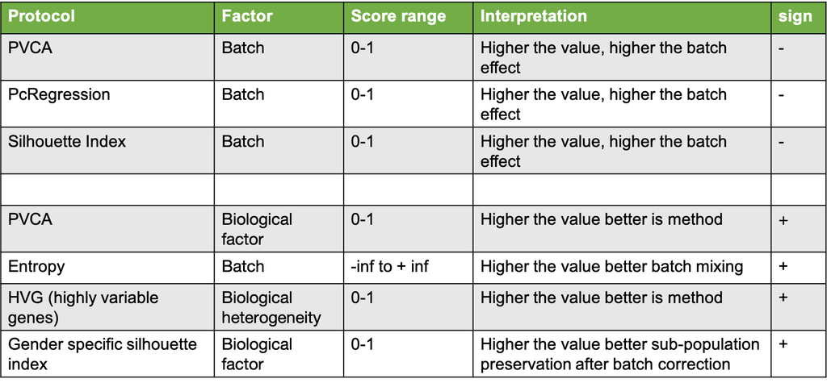

Result interpretation.